# Tidyverse methods for HRI research

## Structure

- A little bit about me
- Reasons for joining R community
- Some recent work using Tidyverse methods
- Future plans

## A bit about me

- Research Associate at Heriot-Watt University
- Background in Psychology
- Currently working on an EPSRC project called SoCoRo (Socially Competent Robots)
- Developing a socially competent robot to modify social signal processing
- Feel free to visit our Twitter: [@socoro2017](http://https://twitter.com/socoro2017)

## Reasons for joining R community

- Psychologist by trade
- Interested in data modelling but not satisfied with SPSS
- Wanted a fully integrated system
- raw data -> data processing -> analysis -> report writing
- Clear and colourful graphs
- Improved workflow: tidy, wrangle, model

## Recent work using tidyverse methods

## Parts of R I'll discuss today

- Introduce main verbs of Tidyverse
- Tidying data
- Dealing with dates
- Dealing with the autism-spectrum quotient (AQ)
- Summarising data
- Plotting data
- Analysis: Binary logistic regression (brief)

## Main verbs of tidyverse

- `filter`: extract rows
- `select`: extract columns
- `gather/spread`: gather columns into rows/spread rows into columns
- `mutate`: compute and append new/existing columns
- `summarise`: summarise data based on stated criteria
- `ntile` : ranking and splitting vectors

## Tidying data using Tidyverse methods pt1

```
# A tibble: 6 x 7
     ID item    expression resp    date       resp_acc  resp_time
  <int> <chr>        <int> <chr>   <chr>      <chr>         <dbl>
1     1 Toast            1 Like    05/09/2017 Correct        6.02
2     1 Milk             2 Like    05/09/2017 Correct        6.45
3     1 Beans            3 Dislike 05/09/2017 Correct        5.48
4     1 Oatmeal          4 Dislike 05/09/2017 Correct        4.21
5     2 Beans            1 Dislike 05/09/2017 Incorrect     11.5
6     2 Toast            2 Like    05/09/2017 Correct        3.58
```

## Tidying data using Tidyverse methods pt 2

```r
resp_data %>%
  filter(ID != "pilot", ID != "3") %>%
  mutate(pad = ifelse(expression %in% c("1", "2"),
                      "Approval", "Disapproval")) %>%
  mutate(ID = as.character(ID)) %>%
  mutate(expression = as.character(expression)) %>%
  select(ID:resp, pad, resp_acc, resp_time) %>%
  arrange(ID)

# remove pilot data, outliers
# more accuracte categories better for graphs
# vectors with numeric values may be categorical; change data type
```

## Tidying data using Tidyverse methods pt 3

```
## # A tibble: 6 x 7
##   ID    item    expression resp    pad         resp_acc resp_time
##   <chr> <chr>   <chr>      <chr>   <chr>       <chr>        <dbl>
## 1 1     Toast   1          Like    Approval    Correct       6.02
## 2 1     Milk    2          Like    Approval    Correct       6.45
## 3 1     Beans   3          Dislike Disapproval Correct       5.48
## 4 1     Oatmeal 4          Dislike Disapproval Correct       4.21
## 5 10    Oatmeal 2          Like    Approval    Correct      19.0
## 6 10    Beans   3          Dislike Disapproval Correct       6.57
```

## Dealing with dates pt 1

```
## # A tibble: 6 x 2
##   dob        expdate
##   <chr>      <chr>
## 1 12/04/1980 05/09/2017
## 2 19/09/1971 05/09/2017
## 3 05/11/1954 05/09/2017
## 4 31/05/1989 05/09/2017
## 5 11/10/1987 05/09/2017
## 6 29/07/1988 07/09/2017
```

## Dealing with dates pt 2

```r
q_data %>%
  select(dob, expdate)   %>%
  mutate(date = as.Date(expdate, "%d/%m/%Y")) %>%
  mutate(birth = as.Date(dob, "%d/%m/%Y")) %>%
  mutate(age = as.numeric(date - birth)/365.2422) %>%
  head
```

```
## # A tibble: 6 x 5
##   dob        expdate    date       birth        age
##   <chr>      <chr>      <date>     <date>     <dbl>
## 1 12/04/1980 05/09/2017 2017-09-05 1980-04-12  37.4
## 2 19/09/1971 05/09/2017 2017-09-05 1971-09-19  46.0
## 3 05/11/1954 05/09/2017 2017-09-05 1954-11-05  62.8
## 4 31/05/1989 05/09/2017 2017-09-05 1989-05-31  28.3
## 5 11/10/1987 05/09/2017 2017-09-05 1987-10-11  29.9
## 6 29/07/1988 07/09/2017 2017-09-07 1988-07-29  29.1
```

## Dealing with the AQ: Using `gather` and `ntile` pt 1

```
## # A tibble: 6 x 4
##   q1                q2                  q3                q4
##   <chr>             <chr>               <chr>             <chr>
## 1 slightly disagree slightly agree      slightly agree    slightly agree
## 2 slightly agree    slightly disagree   definitely agree  slightly agree
## 3 slightly agree    slightly disagree   slightly agree    slightly disagr~
## 4 slightly disagree definitely disagree definitely agree  slightly disagr~
## 5 slightly agree    slightly disagree   definitely agree  slightly disagr~
## 6 slightly agree    slightly disagree   slightly disagree slightly disagr~
```

## Dealing with the AQ: Using `gather` and `ntile` pt 2

```r
q_data %>%
  filter(ID != "pilot", ID != "3") %>%
  select(ID, q1:q50) %>%
  gather(AQ_item, AQ_resp, q1:q50) %>%
  mutate(AQ_num = substring(AQ_item,2)) %>%
  mutate('AQ_score' =
           ifelse(AQ_num %in%
                    c(2,4:7,9,12:13,16,18:23,26,33,35,39,41:43,45:46)
                  & AQ_resp %in%
                    c("definitely agree","slightly agree"), 1,
                  ifelse(AQ_num %in%
                           c(1,3,8,10:11,14:15,17,24:25,27:32,34,36:38,40,44,47:50)
                         & AQ_resp %in%
                           c("slightly disagree","definitely disagree"), 1, 0)))
```

## Dealing with the AQ: Using `gather` and `ntile` pt 3

```
## # A tibble: 6 x 5
##   ID    AQ_item AQ_resp           AQ_num AQ_score
##   <chr> <chr>   <chr>             <chr>     <dbl>
## 1 1     q1      slightly agree    1          0
## 2 2     q1      slightly disagree 1          1.00
## 3 4     q1      slightly agree    1          0
## 4 5     q1      slightly agree    1          0
## 5 6     q1      slightly disagree 1          1.00
## 6 7     q1      slightly agree    1          0
```

## Dealing with the AQ: Using `gather` and `ntile` pt 4

```r
aq %>%
  group_by(ID) %>%
  mutate(AQ_tot = sum(AQ_score)) %>%
  ungroup() %>%
  select(ID, AQ_num, AQ_resp, AQ_score, AQ_tot) %>%
  head
```

## Dealing with the AQ: Using `gather` and `ntile` pt 5

[output not shown]

## Dealing with the AQ: Using `gather` and `ntile` pt 6

```r
aq %>%
  group_by(ID) %>%
  mutate(AQ_tot = sum(AQ_score)) %>%
  ungroup() %>%
  select(ID, AQ_tot) %>%
  distinct() %>%
  mutate(medAQ = ntile(AQ_tot, 2)) %>%
  mutate(AQ_group = recode(medAQ,
                           "1" = "Low AQ",
                           "2" = "High AQ")) %>%
  select(-medAQ) %>%
  head
```

## Dealing with the AQ: Using `gather` and `ntile` pt 7

[output not shown]

## Using summarise to generate frequencies and proportions pt 1

```
## # A tibble: 6 x 5
##   ID    eng                resp    resp_acc resp_time
##   <chr> <chr>              <chr>   <chr>        <dbl>
## 1 1     Native English     Like    Correct       6.02
## 2 1     Native English     Like    Correct       6.45
## 3 1     Native English     Dislike Correct       5.48
## 4 1     Native English     Dislike Correct       4.21
## 5 10    Non-native English Like    Correct      19.0
## 6 10    Non-native English Dislike Correct       6.57
```

## Using summarise to generate frequencies and proportions pt 2

```r
demog_resp %>%
  select(ID, eng, resp) %>%
  group_by(eng, resp) %>%
  summarise(n = n()) %>%
  group_by(eng) %>%
  mutate(freq = n/ sum(n)) %>%
  ungroup
```

## Using summarise to generate frequencies and proportions pt 3

| eng | resp | n | freq |
| --- | --- | --- | --- |
| Native English | Dislike | 72 | 0.5294 |
| Native English | Like | 63 | 0.4632 |
| Native English | Miss | 1 | 0.0074 |
| Non-native English | Dislike | 43 | 0.4886 |
| Non-native English | Like | 41 | 0.4659 |
| Non-native English | Miss | 4 | 0.0455 |

## Plotting resp data using barplot

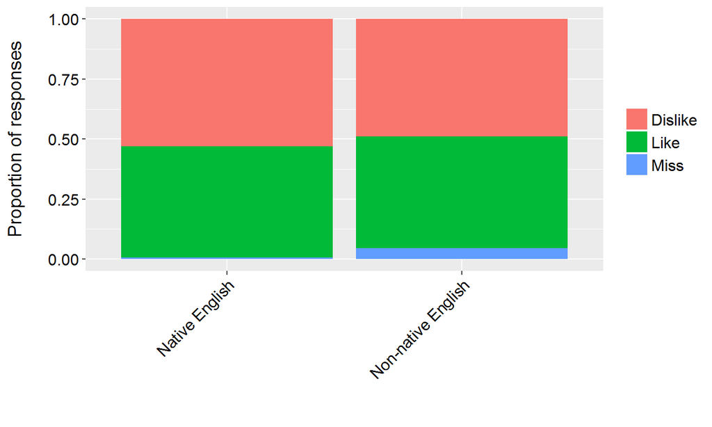

## Plotting resp data with facet

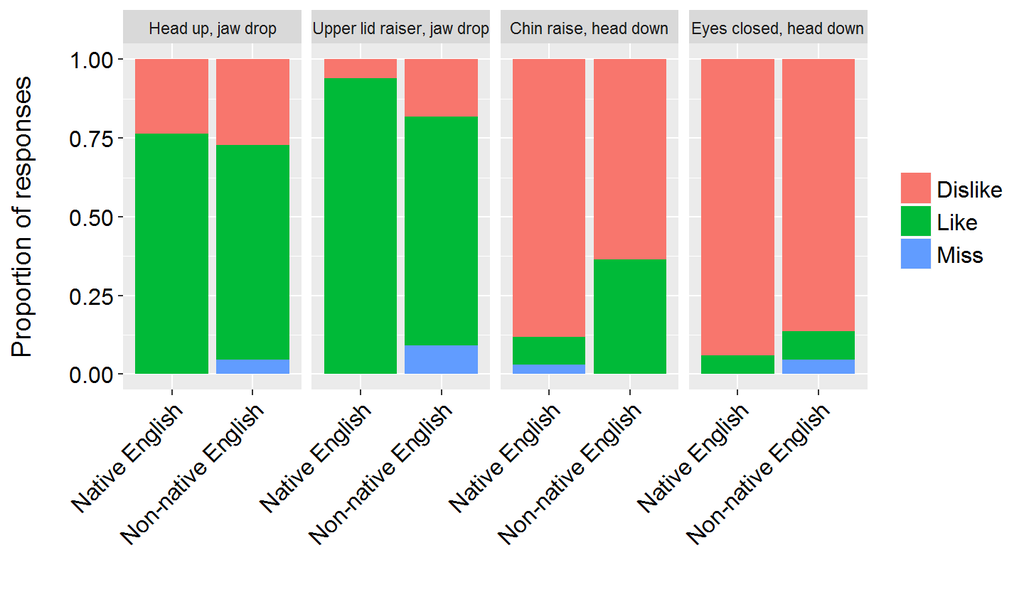

## Plotting questionnaire data pt 1

```r
nat_rob %>%
  group_by(eng, robot_q_item) %>%
  summarise(mean = mean(robot_q_resp),
            median = median(robot_q_resp),
            IQR = IQR(robot_q_resp),
            sd = sd(robot_q_resp),
            n = n()) %>%
  mutate(se = sd / sqrt(n),
         lower_ci = mean - qt(1 - (0.05 / 2), n - 1) * se,
         upper_ci = mean + qt(1 - (0.05 / 2), n - 1) * se) %>%
  mutate("Native Language" = recode(eng,
                      "No" = "Non-native English",
                      "Yes" = "Native English"))
```

## Plotting questionnaire data pt 2

| eng | robot_q_item | mean | median | IQR | sd | n | se | lower_ci | upper_ci | Native Language |
| --- | --- | --- | --- | --- | --- | --- | --- | --- | --- | --- |
| Native English | Friendliness | 3.794 | 4 | 2 | 1.0826 | 136 | 0.0928 | 3.611 | 3.978 | Native English |
| Native English | Interaction_rating | 4.147 | 5 | 1 | 1.0923 | 136 | 0.0937 | 3.962 | 4.332 | Native English |
| Native English | Likeability | 3.618 | 4 | 1 | 1.1159 | 136 | 0.0957 | 3.428 | 3.807 | Native English |
| Native English | Perceived_positiveness | 3.382 | 3 | 1 | 1.0615 | 136 | 0.0910 | 3.202 | 3.562 | Native English |
| Native English | Performance_rating | 3.559 | 4 | 1 | 1.0093 | 136 | 0.0865 | 3.388 | 3.730 | Native English |
| Native English | Voice_clarity | 4.559 | 5 | 1 | 0.8144 | 136 | 0.0698 | 4.421 | 4.697 | Native English |
| Non-native English | Friendliness | 3.682 | 4 | 1 | 0.8241 | 88 | 0.0879 | 3.507 | 3.856 | Non-native English |
| Non-native English | Interaction_rating | 4.273 | 4 | 1 | 0.7540 | 88 | 0.0804 | 4.113 | 4.433 | Non-native English |
| Non-native English | Likeability | 4.227 | 4 | 1 | 0.6013 | 88 | 0.0641 | 4.100 | 4.355 | Non-native English |
| Non-native English | Perceived_positiveness | 3.727 | 4 | 1 | 0.9189 | 88 | 0.0980 | 3.533 | 3.922 | Non-native English |
| Non-native English | Performance_rating | 3.273 | 3 | 1 | 0.8126 | 88 | 0.0866 | 3.100 | 3.445 | Non-native English |
| Non-native English | Voice_clarity | 4.682 | 5 | 1 | 0.5580 | 88 | 0.0595 | 4.564 | 4.800 | Non-native English |

## Plotting questionnaire data pt 3

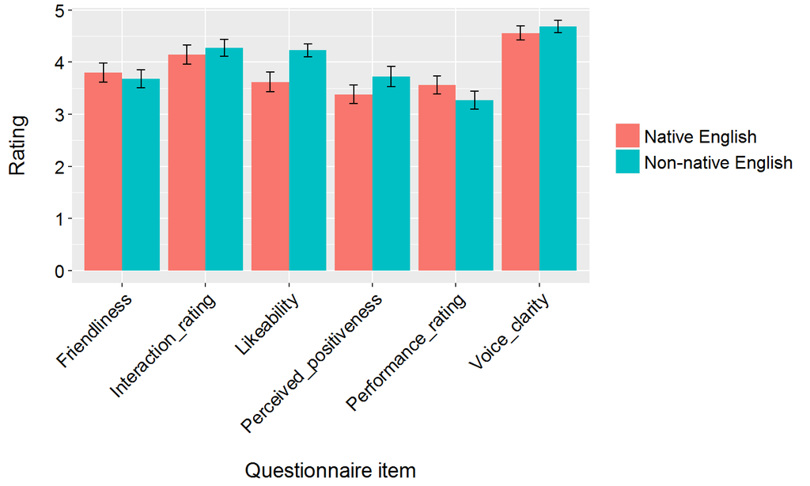

## Plotting response time data by group

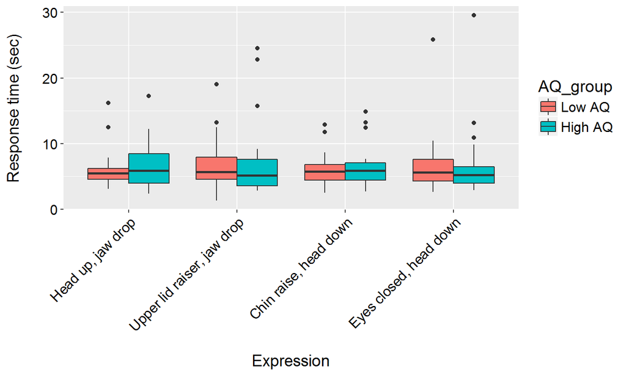

## Data analysis

- Tend to use binary logistic regression; accounts for non-normality
- At present I am not using Tidyverse for analysis. Work in progress…

## Analysis procedure pt 1

- Step one: generate a correlation matrix for numeric vectors

`correl <- cor(aq_a[ , c(8:14)], use = "pairwise.complete.obs")`

`symnum(correl)`

- Evaluate collinearity - decide if need to drop/modify parameters

## Analysis procedure pt 2

- Perform stepwise AIC check on main effect model

`mainmod <- glm(AQ_group ~ expression + eng + sex + resp ..., data = aq_a, family = binomial(link = 'logit'))`

`summary(mainmod)`

- Run a stepwise check of the model predictors

`mod1 <- step(mainmod)`

- Extract lowest AIC model and summarise using `summary`

## Analysis procedure pt 3

- Check is model is significant
- chi-square difference: `chidiff = mod2$null.deviance - mod2$deviance`
- degrees of freedom difference: `dfdiff = mod2$df.null - mod2$df.residual # degrees of freedom difference`

`pchisq(chidiff, dfdiff, lower.tail = F)`

## Analysis procedure pt 4

- Calculate effect size
- use `BaylorEdPsych` package and `PseudoR2` syntax

PseudoR2(mod2)

## Analysis procedure pt 5

- Calculate correctness of model

`correct <- mod2$fitted.values`

- fitted values are a continous porbability of the liklihood of falling into the second group (High_AQ)
- have to convert to binary values
- use 50/50 cut off point as that is chance level for 2 groups

`binarycorrect <- ifelse(correct > 0.5, 1, 0)`

`binarycorrect <- factor(binarycorrect,` `levels = c(0,1),` `labels = c("Low AQ", "High AQ"))`

`table(aq_a$AQ_group, binarycorrect)`

- perform matrix calculations

## Concluding thoughts

- Tidyverse uses logical syntax
- Can tidy, wrangle, and model data with relative ease
- Graphical tool `ggplot2` help visualise trends from multiple perspectives

## Future work

- Eventually want to use R and R Studio as integrated program for all my research activities
- Writing functions to shorten code chunks
- Learn to use tidy methods for analysis
- Setting up a Github repo for version control
- Looking at methods to articulate .rmd with Overleaf

## Thank you

Peter E McKenna

- Email: p.mckenna@hw.ac.uk
- Twitter: @PeterMcKenna89